# **Introduction to Python Project : FoodHub Data Analysis**

### **Observations**:

Multivariate analysis observation on Top restaurants and total time by day of the week

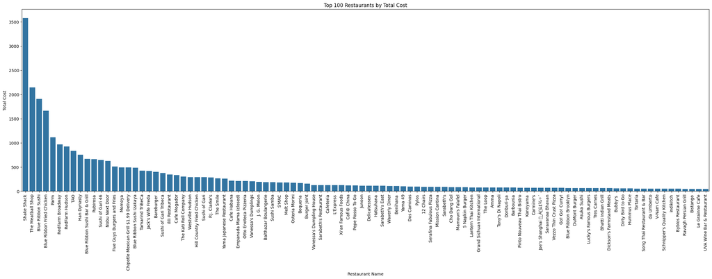

```python
# Multivariate Analysis 6 - Restaurant_name and total_cost_of_the_order
totalCostPerRestaurant = dataCopy.groupby('restaurant_name')['cost_of_the_order'].agg(['count', 'mean', 'sum']).reset_index()
totalCostPerRestaurant = totalCostPerRestaurant.rename(columns={'sum':'total_cost'}) # Corrected: rename 'sum' to 'total_cost'
totalCostPerRestaurant.sort_values(by='total_cost', ascending=False, inplace=True)
plt.figure(figsize=(30, 8))
sns.barplot(data=totalCostPerRestaurant.head(100), x='restaurant_name', y='total_cost')
plt.xticks(rotation=90)
plt.xlabel('Restaurant Name')
plt.ylabel('Total Cost')
plt.title('Top 100 Restaurants by Total Cost')
plt.show()
```

### **Observations** :

Multivariate analysis observation on Restaurant_name and total_cost_of_the_order

1. Most of the revenue (nearly 35%) are from the top 5 restaurants.
2. Top 5 restaurants are below
- Shake Shack
- The Meatball Shop
- Blue Ribbon Sushi
- Blue Ribbon Fried Chicken
- Parm

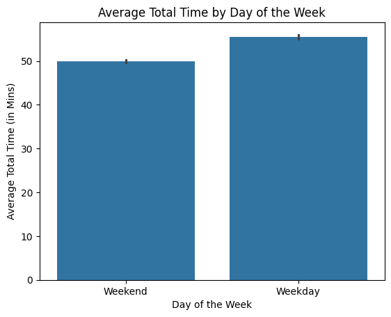

```python
# Multivariate Analysis 7 - Average of total_time and day_of_the_week
dataCopy['total_time'] = dataCopy['food_preparation_time'] + dataCopy['delivery_time']
dataByDay = dataCopy.groupby('day_of_the_week')['total_time'].mean().reset_index

sns.barplot(data=dataCopy, x='day_of_the_week', y='total_time')
plt.xlabel('Day of the Week')
plt.ylabel('Average Total Time (in Mins)')
plt.title('Average Total Time by Day of the Week')
plt.show()

print('_'*60)
```

### **Observations** :

Multivariate analysis observation on Average of total_time and day_of_the_week

1. Average total time (food preparation + delivery time) taken in weekends is lesser than weekdays

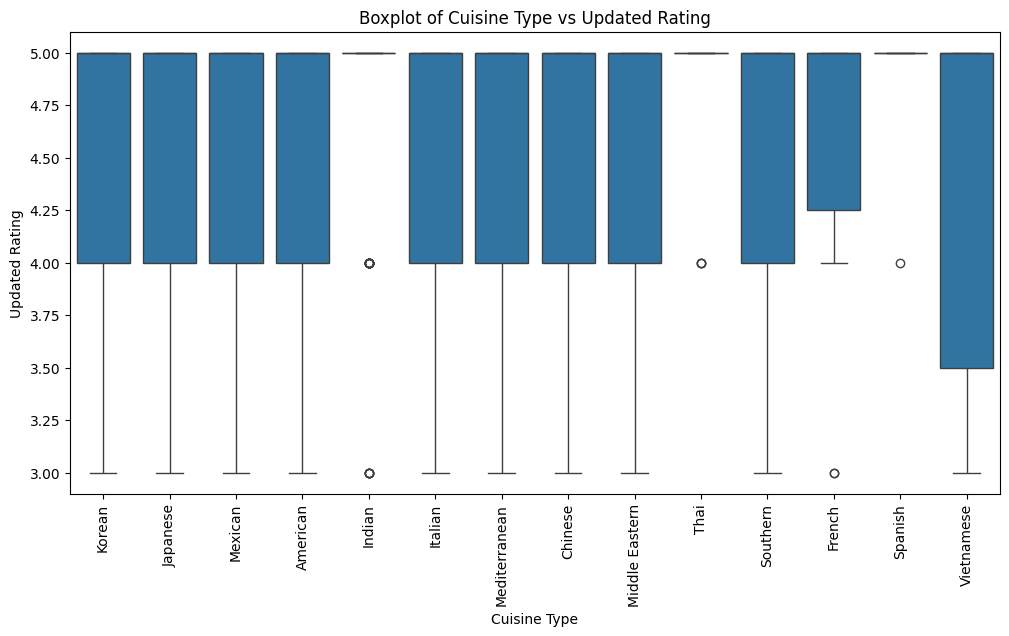

```
____________________________________________________________
```

| cuisine_type | American | Chinese | French | Indian | Italian | Japanese | Korean | Mediterranean | Mexican | Middle Eastern | Southern | Spanish | Thai | Vietnamese |
| --- | --- | --- | --- | --- | --- | --- | --- | --- | --- | --- | --- | --- | --- | --- |
| count | 584.0 | 215.0 | 18.0 | 73.0 | 298.0 | 470.0 | 13.0 | 46.0 | 77.0 | 49.0 | 17.0 | 12.0 | 19.0 | 7.0 |
| mean | 4.558219 | 4.590698 | 4.611111 | 4.684932 | 4.630872 | 4.63617 | 4.384615 | 4.456522 | 4.636364 | 4.469388 | 4.470588 | 4.916667 | 4.842105 | 4.285714 |
| std | 0.683072 | 0.683522 | 0.697802 | 0.598069 | 0.649776 | 0.63445 | 0.767948 | 0.80847 | 0.626374 | 0.680136 | 0.624264 | 0.288675 | 0.374634 | 0.95119 |
| min | 3.0 | 3.0 | 3.0 | 3.0 | 3.0 | 3.0 | 3.0 | 3.0 | 3.0 | 3.0 | 3.0 | 4.0 | 4.0 | 3.0 |
| 25% | 4.0 | 4.0 | 4.25 | 5.0 | 4.0 | 4.0 | 4.0 | 4.0 | 4.0 | 4.0 | 4.0 | 5.0 | 5.0 | 3.5 |
| 50% | 5.0 | 5.0 | 5.0 | 5.0 | 5.0 | 5.0 | 5.0 | 5.0 | 5.0 | 5.0 | 5.0 | 5.0 | 5.0 | 5.0 |
| 75% | 5.0 | 5.0 | 5.0 | 5.0 | 5.0 | 5.0 | 5.0 | 5.0 | 5.0 | 5.0 | 5.0 | 5.0 | 5.0 | 5.0 |
| max | 5.0 | 5.0 | 5.0 | 5.0 | 5.0 | 5.0 | 5.0 | 5.0 | 5.0 | 5.0 | 5.0 | 5.0 | 5.0 | 5.0 |

```python
# Multivariate Analysis 8 - Rating, Restaurant and Cuisine_type

plt.figure(figsize=(12, 6))
sns.boxplot(data=dataCopy, x='cuisine_type', y='updated_rating')
plt.xlabel('Cuisine Type')
plt.ylabel('Updated Rating')
plt.title('Boxplot of Cuisine Type vs Updated Rating')
plt.xticks(rotation=90)
plt.show()

print('_'*60)

dataCopy.groupby('cuisine_type')['updated_rating'].describe().T
```

### **Observations** :

Multivariate analysis observation on Rating, Restaurant and Cuisine_type

1. No cuisines having rating below 3.
2. Top 4 cuisines (American, Japanese, Italian and Chinese received most number or ratings)
3. All the cuisine ratings are higher than or equal to 3

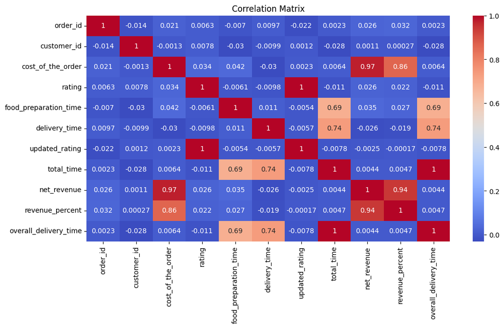

```python
numerical_data = dataCopy.select_dtypes(include=[np.number])
plt.figure(figsize=(12, 6))
sns.heatmap(numerical_data.corr(), annot=True, cmap='coolwarm')
plt.title('Correlation Matrix')
plt.show()
```

### **Observations** :

Multivariate analysis observation on Correlation matrix

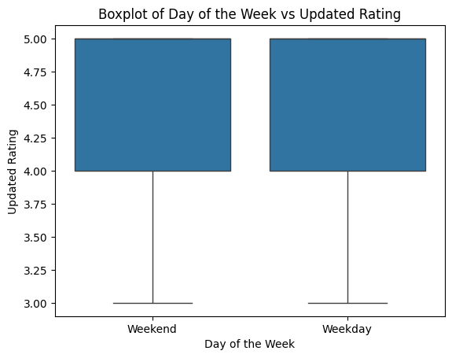

| day_of_the_week | Weekday | Weekend |
| --- | --- | --- |
| count | 547.0 | 1351.0 |
| mean | 4.570384 | 4.609919 |
| std | 0.690119 | 0.650599 |
| min | 3.0 | 3.0 |
| 25% | 4.0 | 4.0 |
| 50% | 5.0 | 5.0 |
| 75% | 5.0 | 5.0 |
| max | 5.0 | 5.0 |

```python
# Multivariate Analysis 10 - Day_of_the_week and rating
sns.boxplot(data=dataCopy, x='day_of_the_week', y='updated_rating')
plt.xlabel('Day of the Week')
plt.ylabel('Updated Rating')
plt.title('Boxplot of Day of the Week vs Updated Rating')
plt.show()

dataCopy.groupby('day_of_the_week')['updated_rating'].describe().T
```

### **Observations** :

Multivariate analysis observation on Day_of_the_week and rating

1. Weekends received most ratings compared to weekdays.
2. overall we have average rating data between 4 and 5, whereas we have some lower data as 3.

### **Question 13:** The company wants to provide a promotional offer in the advertisement of the restaurants. The condition to get the offer is that the restaurants must have a rating count of more than 50 and the average rating should be greater than 4. Find the restaurants fulfilling the criteria to get the promotional offer. [3 marks]

```python
# Write the code here
# Analysis based on imputted data (updated_rating new column)
restaurant_group_data = dataCopy.groupby('restaurant_name')['updated_rating'].agg(['count', 'mean'])

final_restaurants = restaurant_group_data[(restaurant_group_data['count'] > 50) & (restaurant_group_data['mean'] > 4)]

final_restaurants
```

| restaurant_name | count | mean |
| --- | --- | --- |
| Blue Ribbon Fried Chicken | 96 | 4.552083 |
| Blue Ribbon Sushi | 119 | 4.521008 |
| Parm | 68 | 4.5 |
| RedFarm Broadway | 59 | 4.474576 |
| RedFarm Hudson | 55 | 4.490909 |
| Shake Shack | 219 | 4.561644 |
| The Meatball Shop | 132 | 4.689394 |

#### **Observations:**

Based on the imputed rating data, Below restaurants are fulfilling the criteria

| restaurant_name |
| --- |
| Blue Ribbon Fried Chicken |
| Blue Ribbon Sushi |
| Parm |
| RedFarm Broadway |
| RedFarm Hudson |
| Shake Shack |
| The Meatball Shop |

```python
# Write the code here
# Analysis based on real data (rating column) - with NaN
restaurant_group_data = dataCopy.groupby('restaurant_name')['rating'].agg(['count', 'mean'])

final_restaurants = restaurant_group_data[(restaurant_group_data['count'] > 50) & (restaurant_group_data['mean'] > 4)]

final_restaurants
```

| restaurant_name | count | mean |
| --- | --- | --- |
| Blue Ribbon Fried Chicken | 64 | 4.328125 |
| Blue Ribbon Sushi | 73 | 4.219178 |
| Shake Shack | 133 | 4.278195 |
| The Meatball Shop | 84 | 4.511905 |

#### **Observations:**

Based on the actual rating data (With NaN), Below restaurants are fulfilling the criteria

| restaurant_name |
| --- |
| Blue Ribbon Fried Chicken |
| Blue Ribbon Sushi |
| Shake Shack |
| The Meatball Shop |

### **Question 14:** The company charges the restaurant 25% on the orders having cost greater than 20 dollars and 15% on the orders having cost greater than 5 dollars. Find the net revenue generated by the company across all orders. [3 marks]

```python
# Write the code here
dataCopy['revenue_percent'] = 0
dataCopy['net_revenue'] = 0.0

# Apply 15% revenue for orders > 5
dataCopy['revenue_percent'] = np.where(dataCopy['cost_of_the_order'] > 5, 15, dataCopy['revenue_percent'])
dataCopy['net_revenue'] = np.where(dataCopy['cost_of_the_order'] > 5, dataCopy['cost_of_the_order'] * 0.15, dataCopy['net_revenue'])

# Apply 25% revenue for orders > 20 (this overrides the 15% for those specific rows)
dataCopy['revenue_percent'] = np.where(dataCopy['cost_of_the_order'] > 20, 25, dataCopy['revenue_percent'])
dataCopy['net_revenue'] = np.where(dataCopy['cost_of_the_order'] > 20, dataCopy['cost_of_the_order'] * 0.25, dataCopy['net_revenue'])

# Calculating totals amounts to print
total25PercentOrdersAmount = dataCopy[dataCopy['revenue_percent'] == 25]['net_revenue'].sum()
total15PercentOrdersAmount = dataCopy[dataCopy['revenue_percent'] == 15]['net_revenue'].sum()

print('Total orders count having 15% revenue : ', (dataCopy['revenue_percent'] == 15).sum())
print('Total orders count having 25% revenue : ', (dataCopy['revenue_percent'] == 25).sum())

print('Total 15% orders amount : ', total15PercentOrdersAmount)
print('Total 25% orders amount : ', total25PercentOrdersAmount)

print('Net revenue generated by the company across all orders : ', dataCopy['net_revenue'].sum())
```

```
Total orders count having 15% revenue :  1334
Total orders count having 25% revenue :  555
Total 15% orders amount :  2477.5755
Total 25% orders amount :  3688.7275
Net revenue generated by the company across all orders :  6166.303
```

#### **Observations:**

1. Total revenue generated by the company based on the given criteria accross all orders is $6166.303
2. Below are fine grained data
- There are 1334 orders are falls under the 15% charge calculation
- Overall revenue from 15% charge orders is $2477.58
- There are 555 orders are falls under the 25% charge calculation
- Overall revenue from 25% charge orders is $3688.73

### **Question 15:** The company wants to analyze the total time required to deliver the food. What percentage of orders take more than 60 minutes to get delivered from the time the order is placed? (The food has to be prepared and then delivered.) [2 marks]

```python
# Write the code here
dataCopy['overall_delivery_time'] = dataCopy['delivery_time'] + dataCopy['food_preparation_time']
filtered_orders = dataCopy[dataCopy['overall_delivery_time'] > 60]
total_orders = len(dataCopy)
total_filtered_orders = len(filtered_orders)
print("Total number of orders which take more than 60 mins (preparation time + delivery time) : ", total_filtered_orders)
percentage = (total_filtered_orders / total_orders) * 100
print(f"Percentage of orders taking more than 60 minutes to get delivered: {percentage:.2f}%")
```

```
Total number of orders which take more than 60 mins (preparation time + delivery time) :  200
Percentage of orders taking more than 60 minutes to get delivered: 10.54%
```

#### **Observations:**

1. Overall delivery time is calculated based on sum of preparation and delivery time.
2. we considering overall delivery time as filter criteria.
3. Nearly 10.54% of orders (order count - 200) are taking more than 60 mins to get delivered to customers.

### **Question 16:** The company wants to analyze the delivery time of the orders on weekdays and weekends. How does the mean delivery time vary during weekdays and weekends? [2 marks]

```python
# Write the code here
print('Weekday mean average delivery time is ', dataCopy[dataCopy['day_of_the_week'] == 'Weekday']['delivery_time'].mean())
print('Weekend mean average delivery time is ', dataCopy[dataCopy['day_of_the_week'] == 'Weekend']['delivery_time'].mean())
```

```
Weekday mean average delivery time is  28.340036563071298
Weekend mean average delivery time is  22.4700222057735
```

#### **Observations:**

1. The mean average delivery time during weekdays is around 28 minutes.
2. The mean average delivery time during weekends is around 22 minutes.

### Conclusion and Recommendations

### **Question 17:** What are your conclusions from the analysis? What recommendations would you like to share to help improve the business? (You can use cuisine type and feedback ratings to drive your business recommendations.) [6 marks]

### **Conclusions**:

1. There are lot of ratings are missing in the data (Around 39%) which introduce indirect bias in the analysis.
2. Imputted rating data indirectly misguide overall rating analysis (Since huge data is marked as 'Not given')
3. Top 5 restaurants served around 35% of the overall order cost
4. American cuisine is most preferred cuisine type
5. Japanese, Italian and Chinese are next most preferred cuisine types, whereas vietnamese is least preferred.
6. Overall 178 unique restaurants are serving the customers
7. Average cost of the top 4 cuisines equal or below $15
8. Overall delivery time is quicker in the weekends
9. The median cost of order is around $14
10. There is no lower ratings (1 or 2) in the customer feedback
11. Total time taken has no impact on the ratings based on the given data
12. Average cost of the order by the customer per order ranges between $16 and $34

### **Recommendations**:

**1. Start to focus more on getting customer feedback in the form of ratings to increase the trust of the rating data.**

- Include some mechanism to get ratings from customers.
- Integrate follow up mechanism to get the ratings in the usage flow.

- Platform can work to explore some options for faster delivery on the weekends, which will indirectly increase the rating.
- Quality of food needs attention in the weekends, since the volume of orders is more and overall time is less compared to weekdays.

**3. Around 60% of customers ordered more than 1 order. FoodHub can think of some coupon mechanism to encourage customers to use the app for more orders**

- This will indirectly increase the number of orders as well as revenue.
- Increase in order may degrade the overall delivery time, proper delivery planning has to be in place to support for more orders.

**4. On an average, customer spending around $15 per order. By increasing customers favourite cuisines may increase the orders and net revenue.**

**5. Vietnamese cuisine type is least preferred by the customers. Try to attract customers by providing some offers or introduce new set of menus in the vietnamese cuisine to increase visibility across customers.**